# Projekt I Przetwarzanie danych środowiskowych: Wybrane metody regresyjne w analizie danych.

## 3.6 Korelacja zmiennych

W modelu nie powinno się uwzględniać skorelowanych zmiennych, ponieważ będą one dostarczać dwa razy tę samą informację, co nie wpłynie korzystnie na model

Wyświetlono macierz korelacji dla posiadanych parametrów

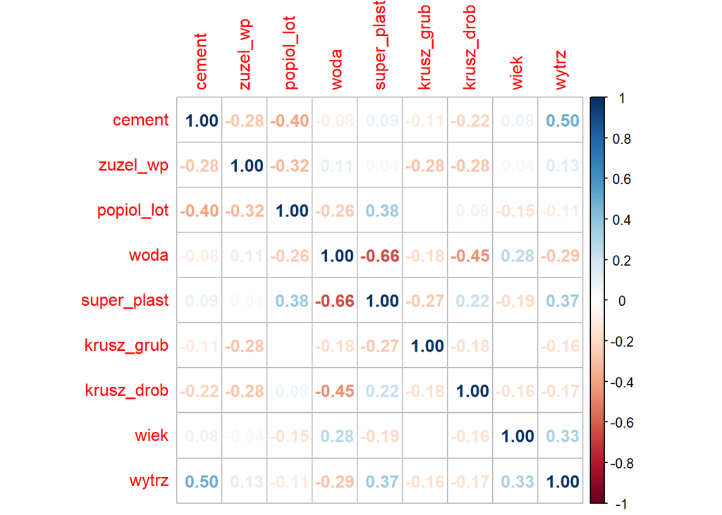

```r
corrplot::corrplot(cor(dt),method = 'number')
```

Zmienne nie są ze sobą istotnie skorelowane. Jedyna bardziej widoczna korelacja występuje między superplastem, a wodą. Sprawdzono jak będzie wyglądać model gdy zostanie z niego wyrzucony jeden z predyktorów. Z wygenerowanego w punkcie 3.3 raportu wiadomo, że superplast jest mniej znaczący od wody, dlatego został usunięty.

```r
dt_bez_sp<-dt[!(colnames(dt)=="super_plast")]

m3_2<-lm(data = dt_bez_sp, formula = wytrz~.*.)
summary(m3_2)
```

```
##
## Call:
## lm(formula = wytrz ~ . * ., data = dt_bez_sp)
##
## Residuals:
##      Min       1Q   Median       3Q      Max
## -26.4130  -5.5468   0.1085   5.5748  31.3085
##
## Coefficients:
##                         Estimate Std. Error t value Pr(>|t|)
## (Intercept)            3.038e+01  1.200e+02   0.253 0.800183
## cement                -1.370e-01  1.169e-01  -1.172 0.241353
## zuzel_wp              -2.124e-01  1.709e-01  -1.243 0.214060
## popiol_lot            -1.278e+00  2.183e-01  -5.857 6.40e-09 ***
## woda                   1.459e+00  3.918e-01   3.723 0.000208 ***
## krusz_grub             7.240e-02  9.536e-02   0.759 0.447890
## krusz_drob            -2.579e-01  7.978e-02  -3.233 0.001264 **
## wiek                  -2.234e-01  4.765e-01  -0.469 0.639284
## cement:zuzel_wp        1.757e-04  5.411e-05   3.247 0.001203 **
## cement:popiol_lot      4.004e-04  7.288e-05   5.494 4.97e-08 ***
## cement:woda           -6.617e-04  2.728e-04  -2.426 0.015460 *
## cement:krusz_grub      1.572e-04  5.949e-05   2.642 0.008368 **
## cement:krusz_drob      2.164e-04  5.329e-05   4.061 5.26e-05 ***
## cement:wiek            6.458e-04  1.790e-04   3.608 0.000324 ***
## zuzel_wp:popiol_lot    5.700e-04  1.046e-04   5.446 6.47e-08 ***
## zuzel_wp:woda         -6.917e-04  3.994e-04  -1.732 0.083616 .
## zuzel_wp:krusz_grub    3.619e-05  7.718e-05   0.469 0.639204
## zuzel_wp:krusz_drob    3.849e-04  6.793e-05   5.666 1.91e-08 ***
## zuzel_wp:wiek          9.528e-04  1.800e-04   5.293 1.48e-07 ***
## popiol_lot:woda        4.936e-04  4.578e-04   1.078 0.281219
## popiol_lot:krusz_grub  4.495e-04  9.611e-05   4.676 3.32e-06 ***
## popiol_lot:krusz_drob  8.110e-04  1.075e-04   7.541 1.04e-13 ***
## popiol_lot:wiek        2.000e-03  2.841e-04   7.040 3.56e-12 ***
## woda:krusz_grub       -1.368e-03  2.535e-04  -5.398 8.43e-08 ***
## woda:krusz_drob       -1.110e-04  1.829e-04  -0.607 0.543990
## woda:wiek             -1.115e-03  7.725e-04  -1.443 0.149199
## krusz_grub:krusz_drob  1.317e-04  6.649e-05   1.981 0.047859 *
## krusz_grub:wiek       -1.121e-04  1.335e-04  -0.840 0.401152
## krusz_drob:wiek        5.223e-04  2.116e-04   2.469 0.013721 *
## ---
## Signif. codes:  0 '***' 0.001 '**' 0.01 '*' 0.05 '.' 0.1 ' ' 1
##
## Residual standard error: 8.603 on 1001 degrees of freedom
## Multiple R-squared:  0.742,  Adjusted R-squared:  0.7348
## F-statistic: 102.8 on 28 and 1001 DF,  p-value: < 2.2e-16
```

```r
cbind(AIC(m3_1,m3_2), BIC(m3_1,m3_2))
```

```
##      df      AIC df      BIC
## m3_1 38 6911.953 38 7099.571
## m3_2 30 7386.922 30 7535.041
```

Na podstawie powyższych parametrów, oceny wskazują, że nowy model wypada gorzej. Przyjrzono się dodatkowo wykresom diagnostycznym.

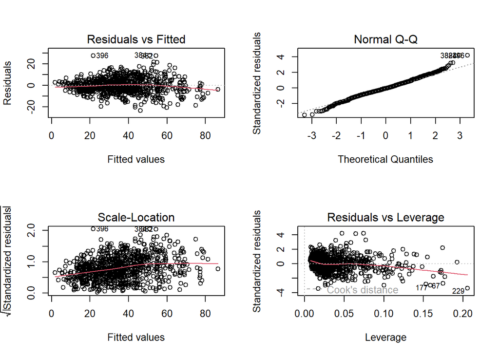

```r
par(mfrow=c(2,2))
plot(m3_1)
```

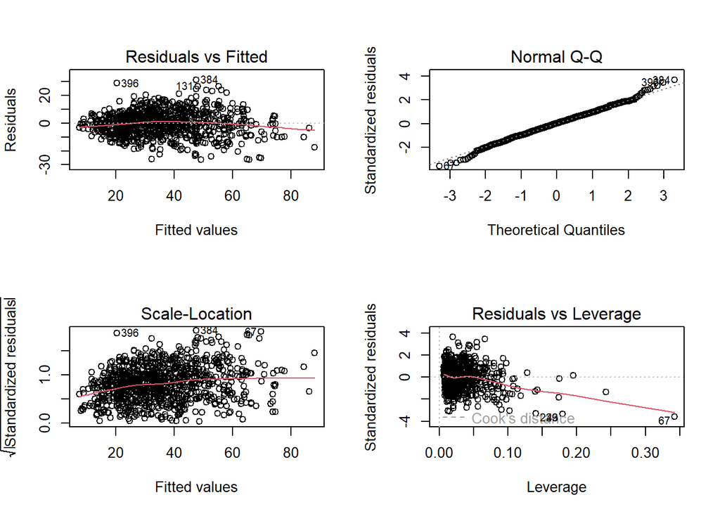

```r
plot(m3_2)
```

Wykres diagnostyczny modelu m3_2 wygląda nieznacznie lepiej. Możliwe, że rozkład reszt jest bardziej zbliżony do normalnego. Sprawdzono to testem statystycznym.

```r
shapiro.test(m3_1$residuals)
```

```
##
##  Shapiro-Wilk normality test
##
## data:  m3_1$residuals
## W = 0.99187, p-value = 1.891e-05
```

```r
shapiro.test(m3_2$residuals)
```

```
##
##  Shapiro-Wilk normality test
##
## data:  m3_2$residuals
## W = 0.99696, p-value = 0.04669
```

Test pokazuje, że reszty modelu m3_2 są bliskie rozkładowi normalnemu, ale normalne nie są.

Na wykresie “Residuals vs Leverage” widać, że występuje jedna obserwacja, która ma duży wpływ na model. Zostało sprawdzone czy model poprawi się, gdy zostanie ona usunięta.

```r
m3_2_1<-lm(data = dt_bez_sp[-67,], formula = wytrz~.*.)
summary(m3_2_1)
```

```
##
## Call:
## lm(formula = wytrz ~ . * ., data = dt_bez_sp[-67, ])
##
## Residuals:
##      Min       1Q   Median       3Q      Max
## -30.5187  -5.4447   0.1615   5.5200  31.3913
##
## Coefficients:
##                         Estimate Std. Error t value Pr(>|t|)
## (Intercept)            3.322e+01  1.193e+02   0.278 0.780701
## cement                -1.089e-01  1.164e-01  -0.935 0.349806
## zuzel_wp              -2.159e-01  1.698e-01  -1.271 0.204070
## popiol_lot            -1.255e+00  2.170e-01  -5.783 9.82e-09 ***
## woda                   1.509e+00  3.897e-01   3.873 0.000115 ***
## krusz_grub             6.820e-02  9.480e-02   0.719 0.472055
## krusz_drob            -2.638e-01  7.932e-02  -3.326 0.000913 ***
## wiek                  -7.945e-01  4.993e-01  -1.591 0.111892
## cement:zuzel_wp        1.623e-04  5.392e-05   3.009 0.002683 **
## cement:popiol_lot      3.839e-04  7.259e-05   5.289 1.51e-07 ***
## cement:woda           -6.855e-04  2.712e-04  -2.527 0.011650 *
## cement:krusz_grub      1.410e-04  5.930e-05   2.378 0.017599 *
## cement:krusz_drob      2.033e-04  5.310e-05   3.828 0.000137 ***
## cement:wiek            7.725e-04  1.814e-04   4.260 2.24e-05 ***
## zuzel_wp:popiol_lot    5.644e-04  1.040e-04   5.425 7.28e-08 ***
## zuzel_wp:woda         -7.735e-04  3.977e-04  -1.945 0.052068 .
## zuzel_wp:krusz_grub    4.627e-05  7.677e-05   0.603 0.546864
## zuzel_wp:krusz_drob    3.935e-04  6.757e-05   5.824 7.76e-09 ***
## zuzel_wp:wiek          1.187e-03  1.903e-04   6.236 6.59e-10 ***
## popiol_lot:woda        4.443e-04  4.553e-04   0.976 0.329380
## popiol_lot:krusz_grub  4.389e-04  9.558e-05   4.592 4.94e-06 ***
## popiol_lot:krusz_drob  8.064e-04  1.069e-04   7.543 1.03e-13 ***
## popiol_lot:wiek        2.160e-03  2.859e-04   7.555 9.41e-14 ***
## woda:krusz_grub       -1.396e-03  2.521e-04  -5.539 3.89e-08 ***
## woda:krusz_drob       -1.495e-04  1.821e-04  -0.821 0.411903
## woda:wiek             -3.772e-04  7.946e-04  -0.475 0.635073
## krusz_grub:krusz_drob  1.424e-04  6.616e-05   2.152 0.031615 *
## krusz_grub:wiek        9.826e-05  1.449e-04   0.678 0.497799
## krusz_drob:wiek        7.453e-04  2.192e-04   3.401 0.000699 ***
## ---
## Signif. codes:  0 '***' 0.001 '**' 0.01 '*' 0.05 '.' 0.1 ' ' 1
##
## Residual standard error: 8.552 on 1000 degrees of freedom
## Multiple R-squared:  0.7453, Adjusted R-squared:  0.7381
## F-statistic: 104.5 on 28 and 1000 DF,  p-value: < 2.2e-16
```

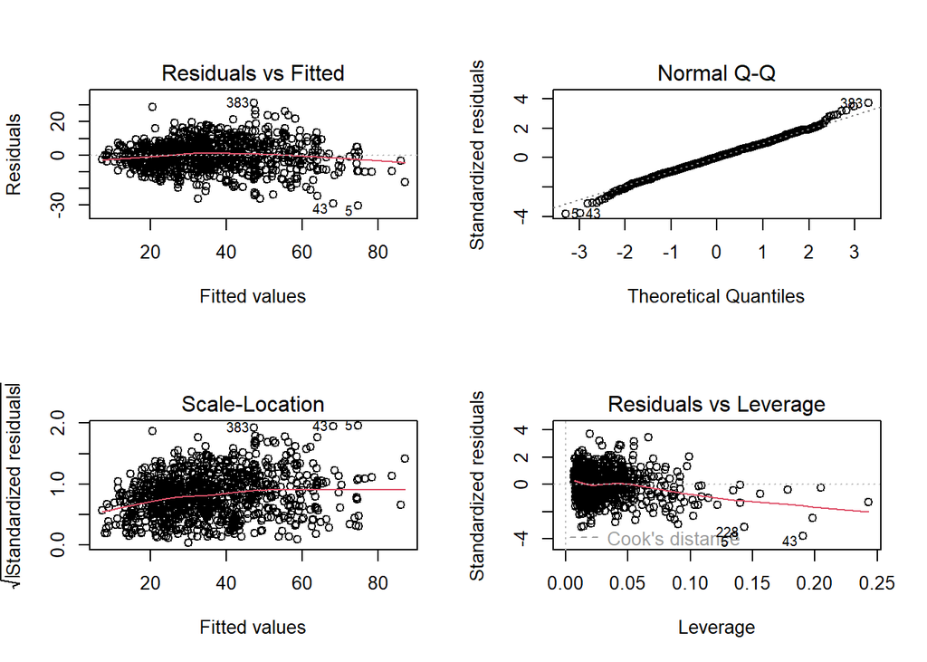

```r
par(mfrow=c(2,2))
plot(m3_2_1)
```

```r
cbind(AIC(m3_1,m3_2_1), BIC(m3_1,m3_2_1)) #kryteria oceny
```

```
##        df      AIC df      BIC
## m3_1   38 6911.953 38 7099.571
## m3_2_1 30 7367.473 30 7515.563
```

Kryteria oceny w dalszym ciągu wychodzą lepiej dla m3_1, który, mimo teoretycznie gorszego rozkładu reszt, wydaje się lepiej dopasowany, a do tego ma wyższy współczynnik R<sup>2</sup>=0.8374.

## 3.7 AIC

Mając wybrany wstępny model można spróbować poprawić go przez AIC w algorytmie krokowym zaimplementowanym w pakiecie *MASS*.

```r
mAIC <- stepAIC(m3_1, direction = "backward", trace = F)
summary(mAIC)
```

```
##
## Call:
## lm(formula = wytrz ~ cement + zuzel_wp + popiol_lot + woda +
##     super_plast + krusz_grub + krusz_drob + wiek + cement:zuzel_wp +
##     cement:popiol_lot + cement:woda + cement:super_plast + cement:krusz_drob +
##     cement:wiek + zuzel_wp:popiol_lot + zuzel_wp:woda + zuzel_wp:krusz_drob +
##     zuzel_wp:wiek + popiol_lot:woda + popiol_lot:super_plast +
##     popiol_lot:krusz_grub + popiol_lot:krusz_drob + popiol_lot:wiek +
##     woda:super_plast + woda:krusz_grub + woda:krusz_drob + super_plast:krusz_grub +
##     krusz_grub:krusz_drob + krusz_grub:wiek + krusz_drob:wiek,
##     data = dt_1)
##
## Residuals:
##      Min       1Q   Median       3Q      Max
## -23.2576  -4.0539  -0.2331   4.1764  28.3790
##
## Coefficients:
##                          Estimate Std. Error t value Pr(>|t|)
## (Intercept)             9.492e+01  8.236e+01   1.153 0.249388
## cement                  1.315e-01  6.451e-02   2.039 0.041763 *
## zuzel_wp               -3.550e-01  8.546e-02  -4.154 3.54e-05 ***
## popiol_lot             -7.494e-01  2.142e-01  -3.499 0.000488 ***
## woda                    1.554e+00  3.174e-01   4.896 1.14e-06 ***
## super_plast            -2.160e+00  1.077e+00  -2.006 0.045109 *
## krusz_grub             -1.709e-02  6.539e-02  -0.261 0.793839
## krusz_drob             -2.992e-01  6.343e-02  -4.717 2.73e-06 ***
## wiek                   -6.436e+01  1.012e+01  -6.360 3.07e-10 ***
## cement:zuzel_wp         1.262e-04  4.039e-05   3.125 0.001831 **
## cement:popiol_lot       2.847e-04  6.191e-05   4.599 4.79e-06 ***
## cement:woda            -1.471e-03  2.374e-04  -6.195 8.53e-10 ***
## cement:super_plast     -2.297e-03  6.554e-04  -3.505 0.000476 ***
## cement:krusz_drob       1.003e-04  3.905e-05   2.568 0.010387 *
## cement:wiek             4.553e-02  5.382e-03   8.460  < 2e-16 ***
## zuzel_wp:popiol_lot     4.195e-04  8.504e-05   4.933 9.47e-07 ***
## zuzel_wp:woda          -7.584e-04  3.062e-04  -2.476 0.013435 *
## zuzel_wp:krusz_drob     3.131e-04  5.108e-05   6.129 1.27e-09 ***
## zuzel_wp:wiek           7.948e-02  6.530e-03  12.172  < 2e-16 ***
## popiol_lot:woda        -1.193e-03  4.507e-04  -2.647 0.008245 **
## popiol_lot:super_plast -3.954e-03  1.275e-03  -3.101 0.001986 **
## popiol_lot:krusz_grub   1.684e-04  8.854e-05   1.902 0.057418 .
## popiol_lot:krusz_drob   5.253e-04  9.511e-05   5.523 4.25e-08 ***
## popiol_lot:wiek         1.019e-01  8.344e-03  12.216  < 2e-16 ***
## woda:super_plast        7.530e-03  3.156e-03   2.386 0.017213 *
## woda:krusz_grub        -9.449e-04  2.118e-04  -4.460 9.11e-06 ***
## woda:krusz_drob        -3.220e-04  1.919e-04  -1.678 0.093690 .
## super_plast:krusz_grub  2.071e-03  7.818e-04   2.649 0.008197 **
## krusz_grub:krusz_drob   1.271e-04  4.759e-05   2.670 0.007708 **
## krusz_grub:wiek         2.296e-02  6.535e-03   3.513 0.000462 ***
## krusz_drob:wiek         4.641e-02  5.420e-03   8.564  < 2e-16 ***
## ---
## Signif. codes:  0 '***' 0.001 '**' 0.01 '*' 0.05 '.' 0.1 ' ' 1
##
## Residual standard error: 6.795 on 999 degrees of freedom
## Multiple R-squared:  0.8394, Adjusted R-squared:  0.8346
## F-statistic:   174 on 30 and 999 DF,  p-value: < 2.2e-16
```

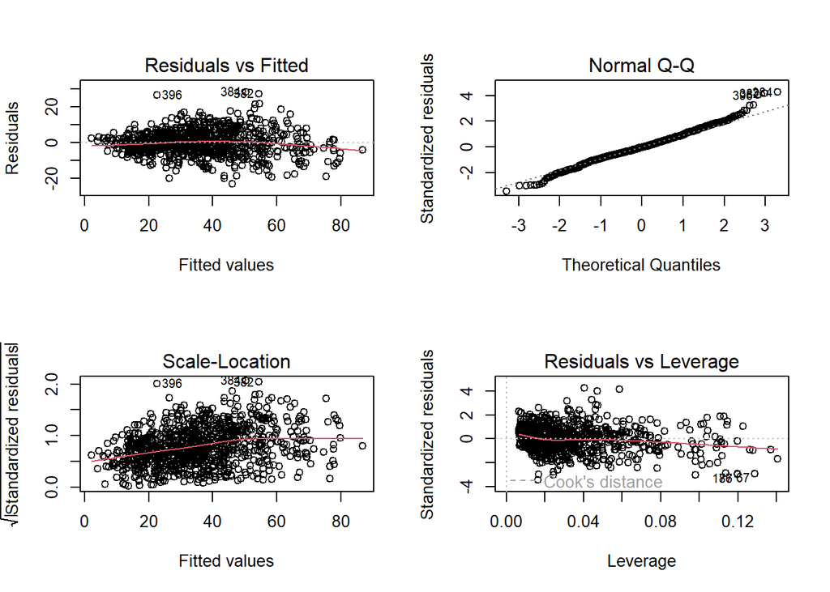

Wykresy oraz raport wskazują na to, że otrzymany model powinien być zadowalającej jakości. Prawdopodobnie jest to najlepszy model jaki udało się uzyskać.

## 3.8 Leaps

W naszym modelu mierzono wiele parametrów. Sprawdzono, czy dałoby się uzyskać podobne wyniki zmniejszając ilość predyktorów:

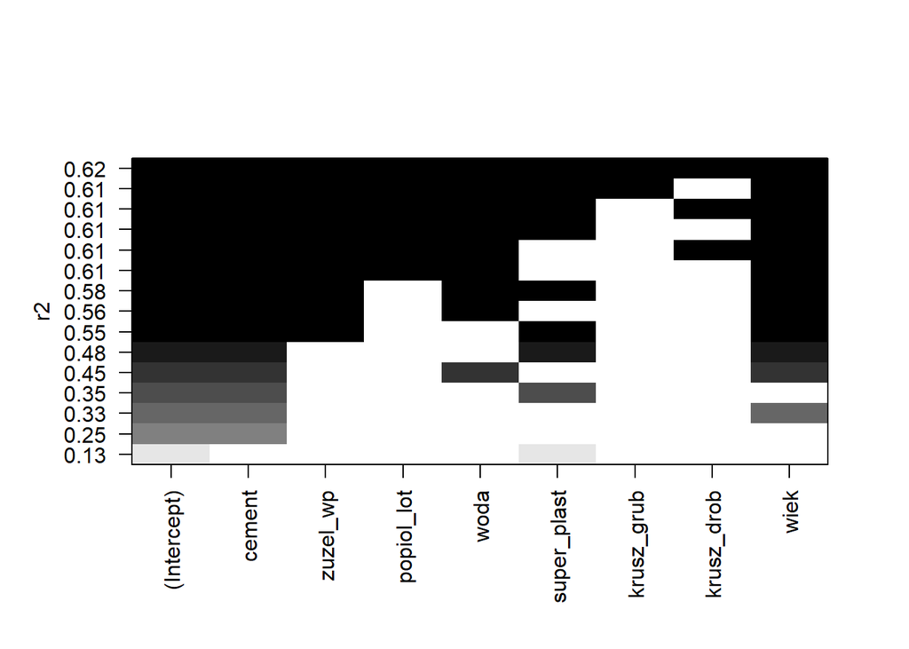

```r
mLEAPS=regsubsets(wytrz~., data=dt,nbest=2)
plot(mLEAPS, scale = "r2")
```

## 3.9 Analiza reszt wybranego modelu

### 3.9.1 Normalność rozkładu reszt

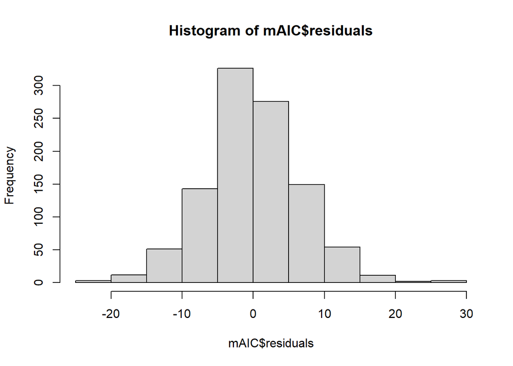

```r
hist(mAIC$residuals, nclass = 18)
```

```r
shapiro.test(mAIC$residuals)
```

```
##
##  Shapiro-Wilk normality test
##
## data:  mAIC$residuals
## W = 0.99192, p-value = 2.023e-05
```

Test statystyczny sugeruje, że reszty nie mają rozkładu normalnego, ale patrząc na histogram można stwierdzić że blisko im do niego.

### 3.9.2 Autokorelacja reszt

```r
dwtest(mAIC)
```

```
##
##  Durbin-Watson test
##
## data:  mAIC
## DW = 1.3939, p-value < 2.2e-16
## alternative hypothesis: true autocorrelation is greater than 0
```

Test wskazuje na występowanie autokorelacji reszt

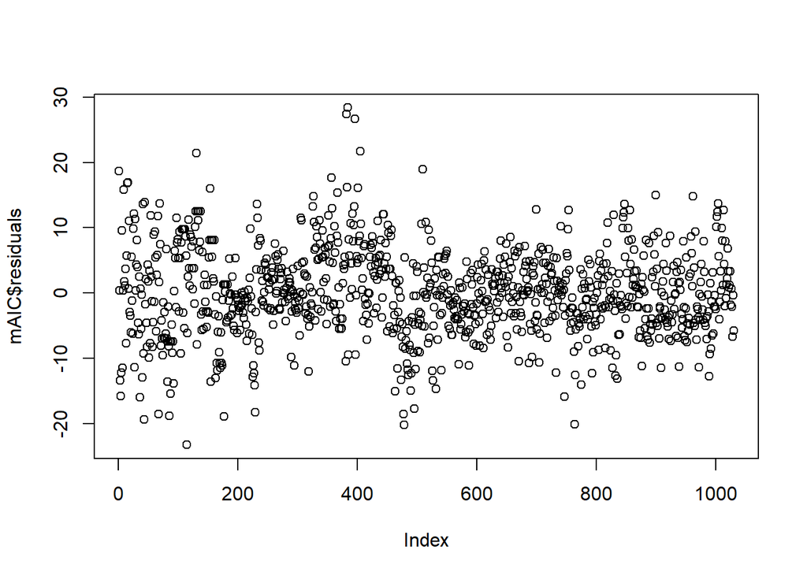

```r
plot(mAIC$residuals)
```

```r
bgtest(m3)
```

```
##
##  Breusch-Godfrey test for serial correlation of order up to 1
##
## data:  m3
## LM test = 96.029, df = 1, p-value < 2.2e-16
```

### 3.9.3 Średnia z reszt

```r
mean(mAIC$residuals)
```

```
## [1] -4.109897e-16
```

Średnia z reszt modelu jest bliska 0.

# 4. Wnioski

Uzyskany model nie spełnia wszystkich kryteriów dobrego modelu. Najprawdopodobniej wynika to z braku liniowej zależności między zmienną objaśnianą, a predyktorami. Mimo wszystko może on dawać zadowalające wyniki. Aby poprawić model można by zastosować regresję sklejaną, która pozwala na zmniejszenie przedziału stosowalności funkcji.